# Data exploration and preprocessing

# Logistic Regression

we will be defining a fucntion here that we will be using to plot the confusion matrices of our models

```python
def confusionMatrix(Matrix):
    fig, ax = plt.subplots(figsize=(7.5, 7.5))
    ax.matshow(Matrix, cmap=plt.cm.Blues, alpha=0.3)
    for i in range(Matrix.shape[0]):
        for j in range(Matrix.shape[1]):
            ax.text(x=j, y=i,s=Matrix[i, j], va='center', ha='center', size='xx-large')

    plt.xlabel('Predictions', fontsize=18)
    plt.ylabel('Actuals', fontsize=18)
    plt.title('Confusion Matrix', fontsize=18)
    plt.show()
```

we will try Logistic regression as our first model

```python
from sklearn.linear_model import LogisticRegression

# Standard logistic regression
lr = LogisticRegression(solver='liblinear').fit(X_train, y_train)
```

```python
from sklearn.metrics import confusion_matrix, accuracy_score, classification_report, f1_score
y_predLR = lr.predict(X_test)
print(classification_report(y_test, y_predLR))
print('Accuracy score: ', round(accuracy_score(y_test, y_predLR), 2))
print('F1 Score: ', round(f1_score(y_test, y_predLR), 2))
```

```
              precision    recall  f1-score   support

         0.0       0.98      0.88      0.93        64
         1.0       0.93      0.99      0.96       107

    accuracy                           0.95       171
   macro avg       0.96      0.93      0.94       171
weighted avg       0.95      0.95      0.95       171

Accuracy score:  0.95
F1 Score:  0.96
```

logistic regression did well with the accuracy,f1 score and precison, but it was decent at the recall score for class 0

```python
conf_matrixLR = confusion_matrix(y_true=y_test, y_pred=y_predLR)
```

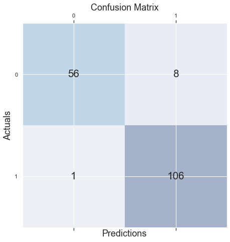

```python
confusionMatrix(conf_matrixLR)
```

from our confusion matrix here we miss classified 8 samples as 1 intead of 0 for the 0 class and we only missclassified 1 sample as 0 instead of 1. which exlpains why our precision was better than the recall

# K-Nearest Neighbor(KNN)

Now lets check our KNN model chosing only 3 neighbors

```python
from sklearn.neighbors import KNeighborsClassifier
knn = KNeighborsClassifier(n_neighbors=3)
knn = knn.fit(X_train, y_train)
y_predKNN = knn.predict(X_test)
```

```python
print(classification_report(y_test, y_predKNN))
print('Accuracy score: ', round(accuracy_score(y_test, y_predKNN), 2))
print('F1 Score: ', round(f1_score(y_test, y_predKNN), 2))
```

```
              precision    recall  f1-score   support

         0.0       0.98      0.92      0.95        64
         1.0       0.95      0.99      0.97       107

    accuracy                           0.96       171
   macro avg       0.97      0.96      0.96       171
weighted avg       0.97      0.96      0.96       171

Accuracy score:  0.96
F1 Score:  0.97
```

Our accuracy here is better than the logistic regresion, alao the recall score has improved a lot

```python
conf_matrixKNN = confusion_matrix(y_true=y_test, y_pred=y_predKNN)
```

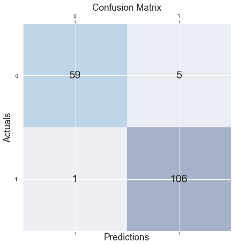

```python
confusionMatrix(conf_matrixKNN)
```

so here we only miss classified 5 samples as 1 instead of 0 (which explains why our recall has improved from that we had in the logistic regression) and again we missclassified only 1 sample as 0 instead of 1.

# Decisicon Tree

Now lets try the decsion tree model. I know that we previouly scaled our data for the KNN and LR models above. and this wont affect the decision tree classifier since trees don't get affected at all with the scaling of our data

```python
from sklearn.tree import DecisionTreeClassifier

dt = DecisionTreeClassifier(random_state=42)
dt = dt.fit(X_train, y_train)
```

```python
dt.tree_.node_count, dt.tree_.max_depth
```

```
(31, 6)
```

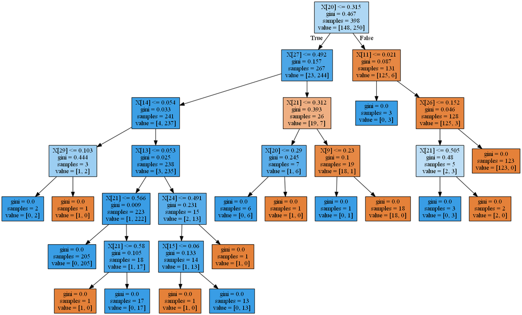

```python
from io import StringIO
from IPython.display import Image
from sklearn.tree import export_graphviz
import pydotplus
dot_data = StringIO()

export_graphviz(dt, out_file=dot_data, filled=True)
graph = pydotplus.graph_from_dot_data(dot_data.getvalue())

filename = 'CancerTree.png'
graph.write_png(filename)
Image(filename=filename)
```

```python
from sklearn.metrics import precision_score, recall_score
def measure_error(y_true, y_pred, label):
    return pd.Series({'accuracy':accuracy_score(y_true, y_pred),
                      'precision': precision_score(y_true, y_pred),
                      'recall': recall_score(y_true, y_pred),
                      'f1': f1_score(y_true, y_pred)},
                      name=label)
```

```python
# The error on the training and test data sets
y_train_pred = dt.predict(X_train)
y_test_pred = dt.predict(X_test)

train_test_full_error = pd.concat([measure_error(y_train, y_train_pred, 'train'),
                              measure_error(y_test, y_test_pred, 'test')],
                              axis=1)

train_test_full_error
```

|  | train | test |
| --- | --- | --- |
| accuracy | 1.0 | 0.918129 |
| precision | 1.0 | 0.934579 |
| recall | 1.0 | 0.934579 |
| f1 | 1.0 | 0.934579 |

our decision tree did perect job in the training data and also a very good job at our testing data.

```python
conf_matrixDT = confusion_matrix(y_true=y_test, y_pred=y_test_pred)
```

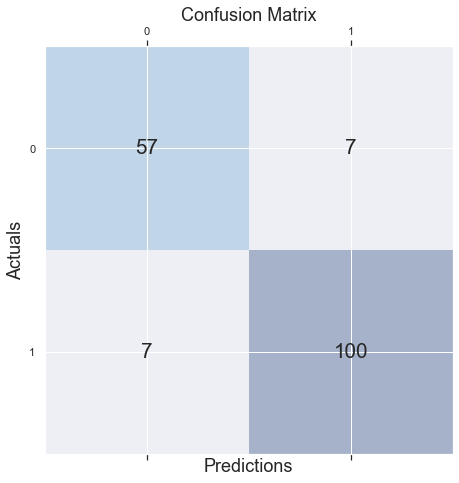

```python
confusionMatrix(conf_matrixDT)
```

so using our confusion matrix just on the test set we can see that in terms of recall our tree did a better job than the LR classifier but not as good as the KNN we can also see that it did a worse job at the recall score than the two previous classifiers

# Conclusion

so Knn is the model recommended here for our problem as it has the best precison,recall,accuracy followed by the Logisitc Regression then the decision tree

# Next steps

Our models can be improved in the future if we used Grid search CV to try to tune these models on the most suitable hyper parameters so we can come up with better resutls